# Assignment2

## PROG8245 Assignment 2: (Total Marks 110)

## Start on 14th of October- Due on 1st of November

- TODO: write your name and ID below
- Name: George Mathew
- ID: 8966959
- Kindly note that this assignment is to be solved by yourself, without the use of AI and chatbots.
- If chatbot usage is detected, the penalty that is discussed in Week 1 slides will apply.
- Each code block will have a Todo comment which explains the functionality, expected input, and expected output of the function.
- There are 10 marks in this assignment for commenting and code readability.

### Part 1: Visualizations (34)

**NOTE:** Each question for plot in the visualization section is expected to be represented in **one** graph, using the library of your choice:

#### **Question 1**

Using the following dataset: https://raw.githubusercontent.com/mwaskom/seaborn-data/master/penguins.csv choose the most convenient graph to show the following: (18 Marks)

**1. The relationship between the penguin's bill length and bill depth for each species.** (5 marks)

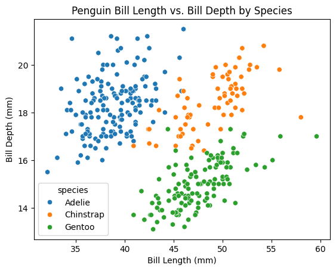

```python
## TODO: Check your attributes, make a graph using Matplotlib or Seaborn to show the relationship needed
import seaborn as sns
import matplotlib.pyplot as plt
import pandas as pd

penguins = pd.read_csv('https://raw.githubusercontent.com/mwaskom/seaborn-data/master/penguins.csv')
sns.scatterplot(data=penguins, x="bill_length_mm", y="bill_depth_mm", hue="species")
plt.title("Penguin Bill Length vs. Bill Depth by Species")
plt.xlabel("Bill Length (mm)")
plt.ylabel("Bill Depth (mm)")
plt.show()
```

**What do you observe from the graph?** (2 marks)

Your answer here:

Overall, the graph suggests that bill length and depth are important characteristics that can help differentiate between these penguin species.

**Why did you choose this type of graph?** (2 marks)

Your answer here:

- The scatter plot was chosen for this data because it effectively shows the relationship between two continuous variables: bill length and bill depth. Here are the key reasons:

  Clarity in Distinguishing Species: The scatter plot clearly separates the three penguin species into distinct clusters, making it easy to observe differences and similarities in bill measurements.

  Visualization of Correlation: This type of graph helps in visualizing any potential correlation between bill length and depth, which can be important for understanding species-specific traits and adaptations.

**2. Suitable graph of the mean BMI (BMI not body_mass; BMI Equation is: weight_in_kg/height^2) of female and male penguins. (Assume the height is the flipper length)** (5 marks)

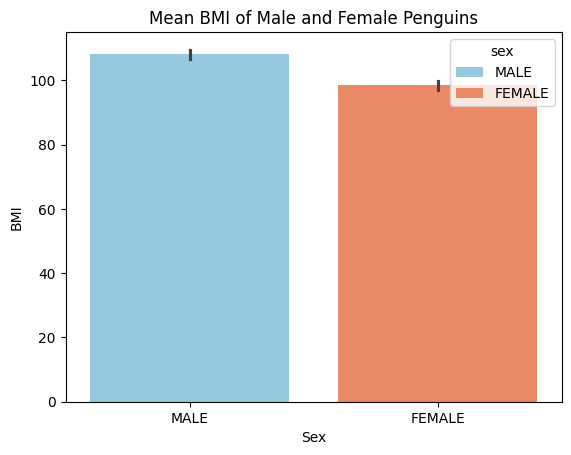

```python
#Your answer here
penguins['weight_kg'] = penguins['body_mass_g'] / 1000
penguins['height_m'] = penguins['flipper_length_mm'] / 1000
penguins['BMI'] = penguins['weight_kg'] / (penguins['height_m'] ** 2)

# Create a color palette for male and female
palette = ['skyblue', 'coral']

# Create the bar plot with different colors based on sex
sns.barplot(
    data=penguins,
    x="sex",
    y="BMI",
    hue="sex",  # Use "hue" argument to assign color based on a column
    palette=palette,  # Set the palette for male and female
)

plt.title("Mean BMI of Male and Female Penguins")
plt.xlabel("Sex")
plt.ylabel("BMI")
plt.show()
```

**What do you observe from the graph?** (2 marks)

Your answer here:

- From the bar chart, we can observe the following:

  Mean BMI Difference: The mean BMI appears to be slightly higher for male penguins compared to female penguins. The bars representing the mean BMI for each sex are visually different in height, with the bar for males being taller than the bar for females.

  Variability: The error bars, which likely represent the standard deviation or confidence intervals, are similar in length for both male and female penguins. This suggests that the variability in BMI within each sex is comparable.

Overall, the graph suggests that, on average, male penguins tend to have a higher BMI than female penguins, but the variability in BMI within each sex is similar.

**Why did you choose this type of graph?** (2 marks)

Your answer here:

- The bar chart was chosen for this data because it effectively compares the mean BMI between two categories: male and female penguins. Here are the key reasons:

  Clear Comparison: Bar charts are excellent for comparing the means of different groups. In this case, it clearly shows the difference in mean BMI between male and female penguins.

  Inclusion of Error Bars: The error bars provide additional information about the variability or standard error in the measurements, which helps in understanding the reliability of the data.

#### **Question 2**

You can find the csv file that contains the museum visitors data here: ./CSVs/museum_visitors.csv (8 marks)

Review the data by taking a look at a few of the rows.

```python
# Your solution here
import pandas as pd
import matplotlib.pyplot as plt

# Read the CSV file
df = pd.read_csv('C:/Users/ASUS/Documents/AAIML/Machine Learning Programming/PROG8245/Data/museum_visitors.csv', index_col='Date', parse_dates=True)

# Display the first few rows
print(df.head())
```

```
            Avila Adobe  Firehouse Museum  Chinese American Museum  \
Date
2014-01-01        24778              4486                     1581
2014-02-01        18976              4172                     1785
2014-03-01        25231              7082                     3229
2014-04-01        26989              6756                     2129
2014-05-01        36883             10858                     3676

            America Tropical Interpretive Center
Date
2014-01-01                                  6602
2014-02-01                                  5029
2014-03-01                                  8129
2014-04-01                                  2824
2014-05-01                                 10694
```

Convince the museum board

The Firehouse Museum claims they ran an event in 2014 that brought an incredible number of visitors, and that they should get extra budget to run a similar event again. The other museums think these types of events aren't that important, and budgets should be split purely based on recent visitors on an average day.

To show the museum board how the event compared to regular traffic at each museum, create a suitable chart that shows how the number of visitors to each museum evolved over time. (4 marks)

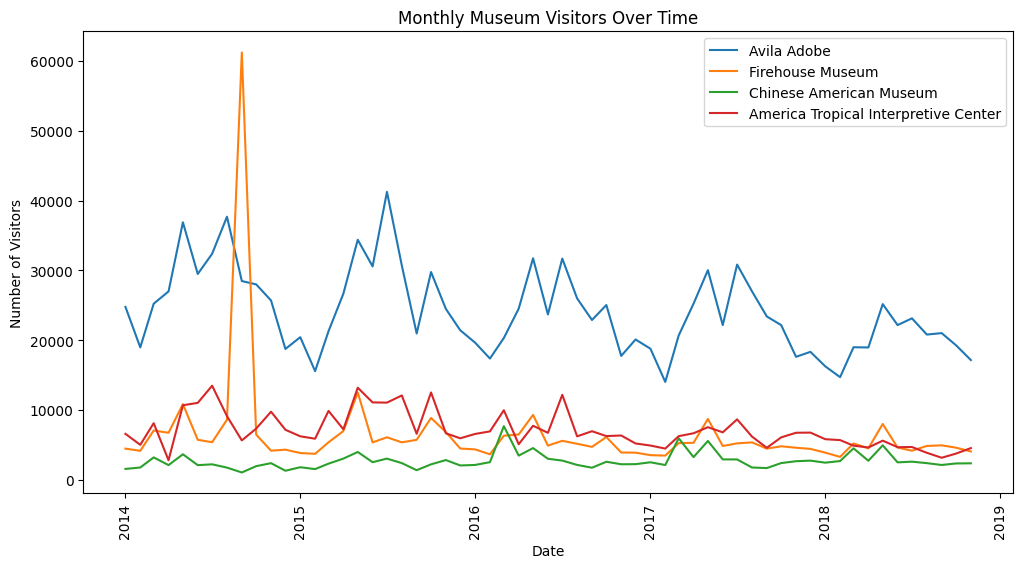

```python
#Your solution here
# Create the line chart
plt.figure(figsize=(12, 6))
for museum in df.columns:
    plt.plot(df.index, df[museum], label=museum)

# Customize the plot
plt.title('Monthly Museum Visitors Over Time')
plt.xlabel('Date')
plt.ylabel('Number of Visitors')
plt.legend()
plt.xticks(rotation=90)
plt.show()
```

What did you observe from the graph? (2 marks)

Your answer here

- Observations from the Graph

  Significant Spike for Firehouse Museum: The Firehouse Museum experienced a notable spike in visitors around mid-2014, indicating a successful event that drew a large crowd.

  Consistent Trends for Other Museums: The other museums (Avila Adobe, Chinese American Museum, America Tropical Interpretive Center) show more consistent visitor numbers over time, without significant spikes.

  Highest Overall Attendance: Avila Adobe consistently has the highest number of visitors compared to the other museums.

These observations suggest that the event at the Firehouse Museum had a significant impact on visitor numbers, which could support their claim for additional budget to run similar events in the future.

Why did you choose this type of graph? (2 marks)

You answer here

- The line graph was chosen for this data because it effectively shows trends and changes in visitor numbers over time. Here are the key reasons:

  Visualization of Trends: Line graphs are excellent for displaying data points over a period, making it easy to observe trends, patterns, and any significant changes, such as the spike in visitors for the Firehouse Museum in mid-2014.

  Comparison Across Multiple Entities: This type of graph allows for the comparison of visitor numbers across multiple museums simultaneously, highlighting differences and similarities in their visitor trends.

#### **Question 3**

Using the file in ./CSVs/gas_prices.csv  
Use a suitable plot/graph that will show the relationship between the average gas price for each country over all years (vs others). (8 marks)

First, review the data by taking a look at a few of the rows.

```python
# Your solution here
import pandas as pd

# Read the CSV file
gas_prices = pd.read_csv('C:/Users/ASUS/Documents/AAIML/Machine Learning Programming/PROG8245/Data/gas_prices.csv')

# Display the first few rows
print(gas_prices.head())
```

```
   Year  Australia  Canada  France  Germany  Italy  Japan  Mexico  \
0  1990        NaN    1.87    3.63     2.65   4.59   3.16    1.00
1  1991       1.96    1.92    3.45     2.90   4.50   3.46    1.30
2  1992       1.89    1.73    3.56     3.27   4.53   3.58    1.50
3  1993       1.73    1.57    3.41     3.07   3.68   4.16    1.56
4  1994       1.84    1.45    3.59     3.52   3.70   4.36    1.48

   South Korea    UK   USA
0         2.05  2.82  1.16
1         2.49  3.01  1.14
2         2.65  3.06  1.13
3         2.88  2.84  1.11
4         2.87  2.99  1.11
```

Then Plot using the most suitable plot on your opinion (5 marks)

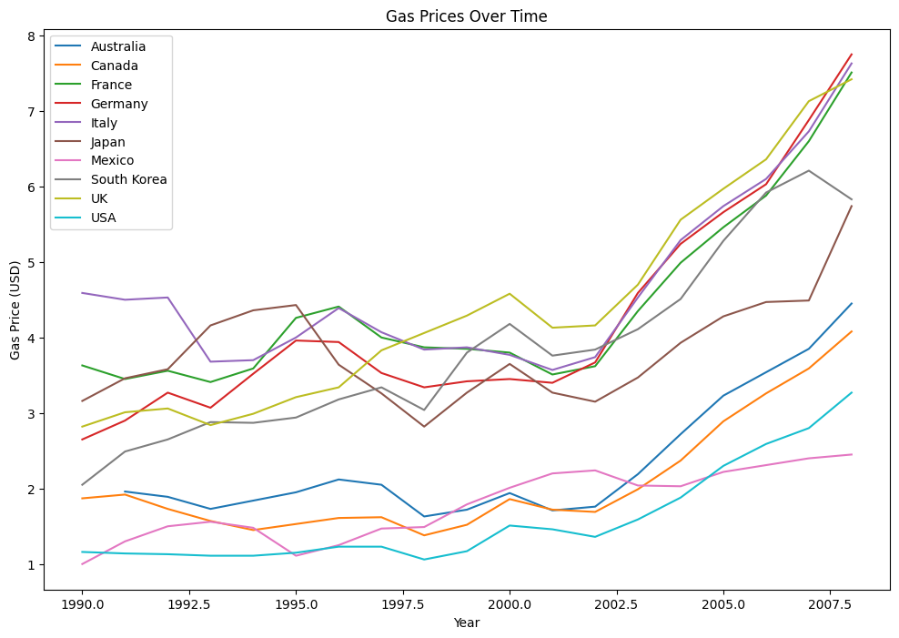

```python
## Your solution here
# Create a line plot for gas prices
plt.figure(figsize=(12, 8))
for column in gas_prices.columns[1:]:
    plt.plot(gas_prices['Year'], gas_prices[column], label=column)

plt.xlabel('Year')
plt.ylabel('Gas Price (USD)')
plt.title('Gas Prices Over Time')
plt.legend()
plt.show()
```

Is there anything interesting observed from the plot/graph? (1 mark)

Your answer here

- Yes, there are several interesting observations from the graph:

  Overall Increase: Gas prices have generally increased from 1990 to 2007 across all countries, reflecting global economic trends and possibly increased demand.

  Country-Specific Trends: The USA consistently has one of the lowest gas prices, while countries like Germany and Italy have higher prices throughout the period.

  Fluctuations: There are noticeable fluctuations in gas prices for each country, with a sharp increase around 2005 for most countries except Mexico, which shows a more gradual rise.

  Comparative Analysis: The graph allows for a comparison of gas price trends between different countries.

These insights provide a comprehensive view of how gas prices have evolved over time in different regions.

Why did you choose this type of graph? (2 marks)

You answer here

- The line graph was chosen for this data because it effectively shows trends and changes in gas prices over time. Here are the key reasons:

  Visualization of Trends: Line graphs are excellent for displaying data points over a period, making it easy to observe trends, patterns, and any significant changes in gas prices from 1990 to 2007.

  Comparison Across Multiple Entities: This type of graph allows for the comparison of gas prices across multiple countries simultaneously, highlighting differences and similarities in their price trends.

### Part 2: Data Tidying and Preprocessing (24)

#### **Question 4:** (12)

**Tuberculosis Dataset** This dataset outlines the number of tuberculosis patients in different countries in the year 2000.  
Dataset name: tb-raw.csv  
A few notes on the raw data set:

- The columns starting with "m" or "f" contain multiple variables:
  - Sex ("m" or "f")
  - Age Group ("0-14","15-24", "25-34", "45-54", "55-64", "65", "unknown")
- Mixture of 0s and missing values("NaN"). This is due to the data collection process and the **distinction** is important for this dataset.
- Task: Apply Data Tidying techniques to get a tidier dataset with more representive columns, please do it step-by-step and explain each step you are doing.

(12 Marks)

```python
df.head()
```

| Date | Avila Adobe | Firehouse Museum | Chinese American Museum | America Tropical Interpretive Center |
| --- | --- | --- | --- | --- |
| 2014-01-01 | 24778 | 4486 | 1581 | 6602 |
| 2014-02-01 | 18976 | 4172 | 1785 | 5029 |
| 2014-03-01 | 25231 | 7082 | 3229 | 8129 |
| 2014-04-01 | 26989 | 6756 | 2129 | 2824 |
| 2014-05-01 | 36883 | 10858 | 3676 | 10694 |

```python
## TODO: Apply your Data Tidying Technique here
import pandas as pd

# Load the dataset
df = pd.read_csv('C:/Users/ASUS/Documents/AAIML/Machine Learning Programming/PROG8245/Data/tb-raw.csv')

# Step-by-step data tidying

# Step 1: Melt the dataframe to unpivot the columns starting with 'm' or 'f'
cols_to_melt = df.columns[2:]
df_melted = df.melt(id_vars=['country', 'year'],
                   value_vars=cols_to_melt,
                   var_name='group',
                   value_name='cases')

# Step 2: Extract 'sex' and 'age_group' from the 'group' column
df_melted['sex'] = df_melted['group'].str[0]

# Define age group categories
age_groups = {
    '014': '0-14',
    '1524': '15-24',
    '2534': '25-34',
    '3544': '35-44',
    '4554': '45-54',
    '5564': '55-64',
    '65': '65+',
    'u': 'unknown'
}
df_melted['age_group'] = df_melted['group'].str[1:].map(age_groups)

# Step 3: Drop the original 'group' column
df_melted.drop('group', axis=1, inplace=True)

# Step 4: Handle mixture of 0s and missing values (NaN) by filling them with 0
df_melted['cases'] = df_melted['cases'].fillna(0)

# Display the tidied dataframe
print(df_melted.head())
```

```
  country  year  cases sex age_group
0      AD  2000    0.0   m      0-14
1      AE  2000    2.0   m      0-14
2      AF  2000   52.0   m      0-14
3      AG  2000    0.0   m      0-14
4      AL  2000    2.0   m      0-14
```

#### Question 5: (12)

Using Boston House pricing dataset, apply outlier detection techniques discussed in class to detect outliers. Use different techniques and comment your code.  
You need to check how to load the dataset correctly!

1. You should include some Visualization techniques
2. You should include some statistical approaches
3. You should analyze your attributes using **Univariant and multivariant** outlier detection techniques.
4. Choose one or more of your outlier detection techniques and remove outliers

```python
# Importing
#data_url = "http://lib.stat.cmu.edu/datasets/boston"
import pandas as pd
import requests

# URL of the dataset
data_url = "http://lib.stat.cmu.edu/datasets/boston"

# Step 1: Fetch data from the URL
response = requests.get(data_url)
raw_text = response.text

# Step 2: Extract data lines, excluding the metadata at the top
data_lines = raw_text.splitlines()[22:]  # Skipping the first 22 lines

# Step 3: Combine every two lines to form complete records
records = []
for idx in range(0, len(data_lines) - 1, 2):
    # Separate and combine two lines of data
    line_one = data_lines[idx].split()
    line_two = data_lines[idx + 1].split()
    records.append(line_one + line_two)  # Concatenate the two lines

# Step 4: Create a DataFrame with appropriate column names
column_names = [
    "CRIM", "ZN", "INDUS", "CHAS", "NOX", "RM", "AGE", "DIS",
    "RAD", "TAX", "PTRATIO", "B", "LSTAT", "MEDV"
]
boston_df = pd.DataFrame(records, columns=column_names).astype(float)

# Displaying the first few rows of the DataFrame to confirm successful loading
print("Preview of Boston Housing Dataset:")
print(boston_df.head())
```

```
Preview of Boston Housing Dataset:
      CRIM    ZN  INDUS  CHAS    NOX     RM   AGE     DIS  RAD    TAX  \
0  0.00632  18.0   2.31   0.0  0.538  6.575  65.2  4.0900  1.0  296.0
1  0.02731   0.0   7.07   0.0  0.469  6.421  78.9  4.9671  2.0  242.0
2  0.02729   0.0   7.07   0.0  0.469  7.185  61.1  4.9671  2.0  242.0
3  0.03237   0.0   2.18   0.0  0.458  6.998  45.8  6.0622  3.0  222.0
4  0.06905   0.0   2.18   0.0  0.458  7.147  54.2  6.0622  3.0  222.0

   PTRATIO       B  LSTAT  MEDV
0     15.3  396.90   4.98  24.0
1     17.8  396.90   9.14  21.6
2     17.8  392.83   4.03  34.7
3     18.7  394.63   2.94  33.4
4     18.7  396.90   5.33  36.2
```

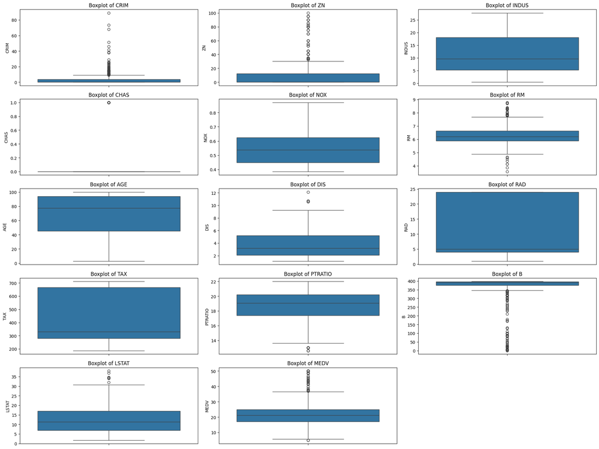

```python
# Univariate Outlier Detection using Boxplot
plt.figure(figsize=(20, 15))
for i, column in enumerate(boston_df.columns, 1):
    plt.subplot(5, 3, i)
    sns.boxplot(y=boston_df[column])
    plt.title(f'Boxplot of {column}')
plt.tight_layout()
plt.show()
```

The box plots reveal several key findings:

```
Presence of Outliers: Many of the box plots show points outside the whiskers, indicating the presence of outliers in multiple variables.

Variation in Data Distribution: Some variables, like CRIM and TAX, have a wide range of values, suggesting significant variation in these features.

Symmetry and Skewness: The distribution of some variables, such as RM and MEDV, appears more symmetric, while others, like LSTAT, show skewness.
```

These insights highlight the importance of addressing outliers and understanding the distribution of each variable for accurate analysis and modeling.

```python
import numpy as np
from scipy import stats

# Multivariate Outlier Detection using Z-Score
z_scores = np.abs(stats.zscore(boston_df))
outliers = np.where(z_scores > 3)

# Display the outliers
print("Outliers detected using Z-Score method:")
print(outliers)

# Find the number of unique rows having outliers
unique_outlier_rows = np.unique(outliers[0])
num_outlier_rows = len(unique_outlier_rows)

print(f"Number of rows with outliers: {num_outlier_rows}")
```

```
Outliers detected using Z-Score method:
(array([ 55,  56,  57, 102, 141, 142, 152, 154, 155, 160, 162, 163, 199,
       200, 201, 202, 203, 204, 208, 209, 210, 211, 212, 216, 218, 219,
       220, 221, 222, 225, 234, 236, 256, 257, 262, 269, 273, 274, 276,
       277, 282, 283, 283, 284, 347, 351, 352, 353, 353, 354, 355, 356,
       357, 358, 363, 364, 364, 365, 367, 369, 370, 372, 373, 374, 374,
       380, 398, 404, 405, 406, 410, 410, 411, 412, 412, 414, 414, 415,
       416, 418, 418, 419, 423, 424, 425, 426, 427, 427, 429, 431, 436,
       437, 438, 445, 450, 454, 455, 456, 457, 466], dtype=int64), array([ 1,  1,  1, 11, 12,  3,  3,  3,  3,  3,  3,  3,  1,  1,  1,  1,  1,
        1,  3,  3,  3,  3,  3,  3,  3,  3,  3,  3,  3,  5,  3,  3,  1,  5,
        5,  3,  3,  3,  3,  3,  3,  1,  3,  1,  1,  7,  7,  1,  7,  7,  7,
        3,  3,  3,  3,  3,  5,  5,  5,  3,  3,  3, 12,  5, 12,  0,  0,  0,
        0,  5,  0, 11, 11, 11, 12,  0, 12, 11, 11,  0, 11, 11, 11, 11, 11,
       11,  0, 11, 11, 11, 11, 11, 11, 11, 11, 11, 11, 11, 11, 11],
      dtype=int64))
Number of rows with outliers: 91
```

```python
# Remove outliers based on Z-Score method
boston_df_cleaned = boston_df[(z_scores < 3).all(axis=1)]

# Display the cleaned dataset
print("Cleaned dataset after removing outliers:")
print(boston_df_cleaned.head())
```

```
Cleaned dataset after removing outliers:
      CRIM    ZN  INDUS  CHAS    NOX     RM   AGE     DIS  RAD    TAX  \
0  0.00632  18.0   2.31   0.0  0.538  6.575  65.2  4.0900  1.0  296.0
1  0.02731   0.0   7.07   0.0  0.469  6.421  78.9  4.9671  2.0  242.0
2  0.02729   0.0   7.07   0.0  0.469  7.185  61.1  4.9671  2.0  242.0
3  0.03237   0.0   2.18   0.0  0.458  6.998  45.8  6.0622  3.0  222.0
4  0.06905   0.0   2.18   0.0  0.458  7.147  54.2  6.0622  3.0  222.0

   PTRATIO       B  LSTAT  MEDV
0     15.3  396.90   4.98  24.0
1     17.8  396.90   9.14  21.6
2     17.8  392.83   4.03  34.7
3     18.7  394.63   2.94  33.4
4     18.7  396.90   5.33  36.2
```

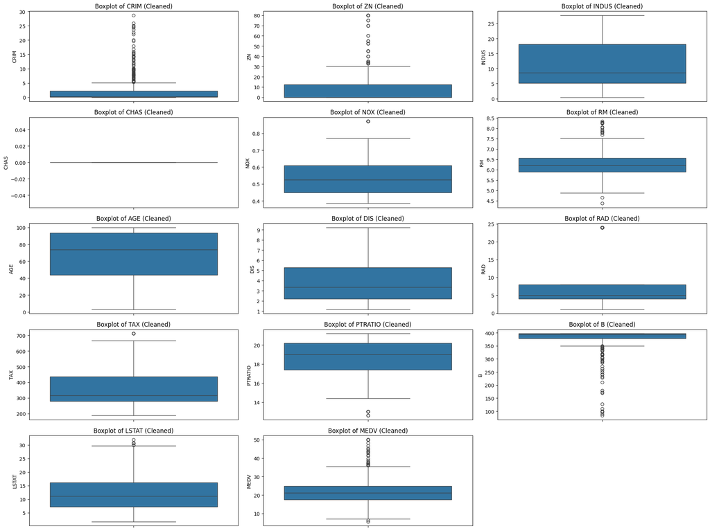

```python
# Visualization of cleaned data using Boxplot
plt.figure(figsize=(20, 15))
for i, column in enumerate(boston_df_cleaned.columns, 1):
    plt.subplot(5, 3, i)
    sns.boxplot(y=boston_df_cleaned[column])
    plt.title(f'Boxplot of {column} (Cleaned)')
plt.tight_layout()
plt.show()
```

The box plots after outlier removal reveal several key insights:

[output not shown]

Overall, the removal of outliers has led to a more consistent and reliable dataset, which is crucial for accurate statistical analysis and modeling.

### Part 3: Feature Engineering (17)

#### Question 6- Feature Engineering - Attribute Correlation (17)

- Load the file income_data.csv, inspect the columns.
- Determine if race and education features have a statistical relationship.
- Explain and conclude your findings (7 till here)
- Inspect the dataset carefully and create an Indicator Feature (0/1) --(3)
- Inspect the dataset carefully and create an Interaction Feature (Additional feature engineered from your dataset)-- (3)

**The features you create must be resonable, please add an explanation to explain why did you chose those features** (2 for each explanation -> 4)

```python
## TODO: Start Question 6 code here
from scipy.stats import chi2_contingency

# Load the data
data = pd.read_csv("C:/Users/ASUS/Documents/AAIML/Machine Learning Programming/PROG8245/Data/income_data.csv")
print(data.head())

# Inspect the columns
print("Columns in the dataset:")
print(data.columns)

# Create a contingency table
contingency_table = pd.crosstab(data['race'], data['education'])

# Perform Chi-Square test
chi2, p, dof, expected = chi2_contingency(contingency_table)

print("\nChi-Square Test Results:")
print(f"Chi2 Statistic: {chi2}")
print(f"P-Value: {p}")

if p < 0.05:
    print("There is a significant relationship between race and education.")
else:
    print("There is no significant relationship between race and education.")
```

```
   age  workclass  fnlwgt     education  educational-num      marital-status  \
0   25    Private  226802          11th                7       Never-married
1   38    Private   89814       HS-grad                9  Married-civ-spouse
2   28  Local-gov  336951    Assoc-acdm               12  Married-civ-spouse
3   44    Private  160323  Some-college               10  Married-civ-spouse
4   18          ?  103497  Some-college               10       Never-married

          occupation relationship   race  gender  capital-gain  capital-loss  \
0  Machine-op-inspct    Own-child  Black    Male             0             0
1    Farming-fishing      Husband  White    Male             0             0
2    Protective-serv      Husband  White    Male             0             0
3  Machine-op-inspct      Husband  Black    Male          7688             0
4                  ?    Own-child  White  Female             0             0

   hours-per-week native-country income
0              40  United-States  <=50K
1              50  United-States  <=50K
2              40  United-States   >50K
3              40  United-States   >50K
4              30  United-States  <=50K
Columns in the dataset:
Index(['age', 'workclass', 'fnlwgt', 'education', 'educational-num',
       'marital-status', 'occupation', 'relationship', 'race', 'gender',
       'capital-gain', 'capital-loss', 'hours-per-week', 'native-country',
       'income'],
      dtype='object')

Chi-Square Test Results:
Chi2 Statistic: 1040.6622432490267
P-Value: 7.472985630264855e-179
There is a significant relationship between race and education.
```

Based on the results of the Chi-Square test, we can conclude that race and education are not independent variables. There is a significant relationship between the two. This suggests that certain racial groups may have different educational attainment levels, potentially due to various socio-economic factors.

```python
# Create an Indicator Feature
data['high_education'] = data['educational-num'].apply(lambda x: 1 if x >= 13 else 0)
print("\nIndicator Feature 'high_education' created:")
print(data[['education', 'educational-num', 'high_education']].head())
```

```
Indicator Feature 'high_education' created:
      education  educational-num  high_education
0          11th                7               0
1       HS-grad                9               0
2    Assoc-acdm               12               0
3  Some-college               10               0
4  Some-college               10               0
```

The high_education indicator feature is created to identify individuals with higher education levels. This feature can be useful in predicting income levels, as higher education is often associated with higher income.

```python
# Create an Interaction Feature
data['race_gender_interaction'] = data['race'] + "_" + data['gender']
print("\nInteraction Feature 'race_gender_interaction' created:")
print(data[['race', 'gender', 'race_gender_interaction']].head())
```

```
Interaction Feature 'race_gender_interaction' created:
    race  gender race_gender_interaction
0  Black    Male              Black_Male
1  White    Male              White_Male
2  White    Male              White_Male
3  Black    Male              Black_Male
4  White  Female            White_Female
```

The race_gender_interaction feature is created to capture the combined effect of race and gender on income. This interaction might reveal patterns that are not evident when considering race and gender separately.

[figure not shown]

```python
import seaborn as sns
import matplotlib.pyplot as plt

# Visualize the relationship using a heatmap
plt.figure(figsize=(10, 6))
sns.heatmap(contingency_table, annot=True, cmap='YlGnBu')
plt.title('Heatmap of Race vs Education')
plt.show()
```

The heatmap provides a visual representation of the distribution of education levels among different racial categories. Here are some key observations:

[output not shown]

This heatmap effectively highlights the disparities in educational attainment among different racial groups

### Part 4: Challenging Preprocessing Problems

#### Question 7: Implementing the Local Outlier Factor (LOF) Function (25)

- Local outlier factor is a function that labels outlier based on 2 predefined parameters, the first one is t **k** for k-Nearest-Neighbours. The second one is the threshold of outliers which could be set arbitrary. However, in this coding task you are required to BOX-PLOTS to determine the threshold for the local outlier factor and label your outliers.
- You are expected to implement different functions to reach the target which will be defined below.

```python
def get_outliers(list_of_points, K=2, distance_approach="Euclidean"):
    ## TODO: This function uses the get_points_lof to get the LOF scores, and uses is to build a box-plot
    ## Using the box-plot points are labelled as outliers are returned to the user
    ## Example: if point (2,1) and (3,2) are labelled as outliers using box-plot
    ## Then you will return the example given in the place-holder below
    lof_scores = get_points_lof(list_of_points, K, distance_approach)

    # Use box-plot to determine the threshold for outliers
    lof_values = np.array(list(lof_scores.values()))

    plt.figure(figsize=(10, 6))
    plt.boxplot(lof_values)
    plt.title("Box-Plot of LOF Scores")
    plt.show()

    Q1 = np.percentile(lof_values, 25)
    Q3 = np.percentile(lof_values, 75)
    IQR = Q3 - Q1
    threshold = Q3 + 1.5 * IQR

    outliers = [point for point in lof_scores if lof_scores[point] > threshold]

    return outliers
```

##### To calculate the LOF you need to apply the following steps:

1. Calculate the distance between each pair of points p1,p2
2. Find your Kth nearest neighbor point (x) from current point (p):
   - After finding it, remember the distance *Nd* which is the distance from p to x, and save a set of elements which are in a neighborhood of *Nd* around point p.
   - Save the length of this set of elements.
3. Calculate ReachDistance(x,p)=max(Nd_x, Distance(x,p))
4. Calculate LRD (Local Reachability Distance) where LRD_p = length_of_set_p/Sum[ReachDistance(x,p)] (for each x in set of elements of point p)
5. Calculate LOF (Local Outlier Factor) where LOF_p = {Sum[LRD_x] (for each x in set of elements of point p) * Sum[RD(x,p)] (for each x in set of elements of point p)} / length_of_set_p^2

```python
# 1.
def calculate_point_to_point_distance(point_a, point_b, distance_approach="Euclidean"):
    ## TODO: This function takes as an input two points (where each point is a pair of (x,y)) and returns the distance between the points.
    ## The distance is calculate based on given distance_approach
    ## You need to handle the Euclidean and Manhattan Distance Approaches in your code
    if distance_approach == "Euclidean":
        return np.sqrt((point_a[0] - point_b[0])**2 + (point_a[1] - point_b[1])**2)
    elif distance_approach == "Manhattan":
        return abs(point_a[0] - point_b[0]) + abs(point_a[1] - point_b[1])
    return 0

# 2.
def get_k_nearest_neighbors(point, list_of_points, K, distance_approach):
    distances = []
    for other_point in list_of_points:
        if other_point != point:
            distance = calculate_point_to_point_distance(point, other_point, distance_approach)
            distances.append((distance, other_point))
    distances.sort(key=lambda x: x[0])
    return distances[:K]

# 3.
def calculate_reachability_distance(point, neighbor, list_of_points, K, distance_approach):
    k_nearest_neighbors = get_k_nearest_neighbors(neighbor, list_of_points, K, distance_approach)
    k_distance = k_nearest_neighbors[-1][0]
    actual_distance = calculate_point_to_point_distance(point, neighbor, distance_approach)
    return max(k_distance, actual_distance)

# 4.
def calculate_lrd(point, list_of_points, K, distance_approach):
    k_nearest_neighbors = get_k_nearest_neighbors(point, list_of_points, K, distance_approach)
    reachability_distances = [calculate_reachability_distance(point, neighbor[1], list_of_points, K, distance_approach) for neighbor in k_nearest_neighbors]
    return len(k_nearest_neighbors) / sum(reachability_distances)

# 5.
def get_points_lof(list_of_points, K=2, distance_approach = "Euclidean"):
    ## TODO: This function takes a list of points and returns a dictionary
    ## The dictionary is in format {point: LOF, ...}
    ## You can use as much helper functions as you'd like
    lrd_dict = {}
    for point in list_of_points:
        lrd_dict[tuple(point)] = calculate_lrd(point, list_of_points, K, distance_approach)

    lof_dict = {}
    for point in list_of_points:
        k_nearest_neighbors = get_k_nearest_neighbors(point, list_of_points, K, distance_approach)
        lrd_ratios = [lrd_dict[tuple(neighbor[1])] / lrd_dict[tuple(point)] for neighbor in k_nearest_neighbors]
        lof_dict[tuple(point)] = sum(lrd_ratios) / len(k_nearest_neighbors)

    return lof_dict
```

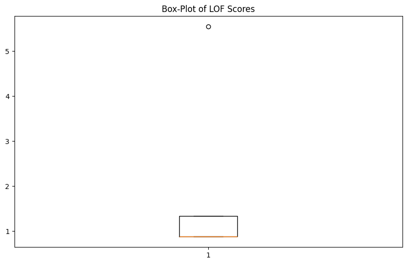

```
Outliers: [(5, 5)]
```

```python
## Example input
list_of_points = [[0,0],[-1,0],[0,-1],[1,0],[5,5]]
# get_outliers(list_of_points,2,distance_approach="Manhattan") ==> [(5,5)]


outliers_f = get_outliers(list_of_points,2,distance_approach="Manhattan")
print("Outliers:", outliers_f)
```